# Non-linear latent variable models and error-in-variable models

Klaus Kähler Holst

2023-02-25

```r
library('lava')
```

We consider the measurement models given by

$$X_{j} = \eta_{1} + \epsilon_{j}^{x},
\quad j=1,2,3$$
$$Y_{j} = \eta_{2} +
\epsilon_{j}^{y}, \quad j=1,2,3$$
and with a structural model given by
$$\eta_{2} = f(\eta_{1}) + Z +
\zeta_{2}\label{ex:eta2}$$
$$\eta_{1}
= Z + \zeta_{1}\label{ex:eta1}$$
with iid measurement errors $\epsilon_{j}^{x},\epsilon_{j}^{y},\zeta_{1},\zeta_{2}\sim\mathcal{N}(0,1), j=1,2,3.$ and standard normal distributed covariate $Z$. To simulate from this model we use the following syntax:

```r
f <- function(x) cos(1.25*x) + x - 0.25*x^2
m <- lvm(x1+x2+x3 ~ eta1, y1+y2+y3 ~ eta2, latent=~eta1+eta2)
regression(m) <- eta1+eta2 ~ z
functional(m, eta2~eta1) <- f

d <- sim(m, n=200, seed=42) # Default is all parameters are 1
```

```r
plot(m, plot.engine="visNetwork")
```

[interactive chart not shown]

We refer to <sup>holst_budtzjorgensen_2013</sup> for details on the syntax for model specification.

# Estimation

To estimate the parameters using the two-stage estimator described in <sup>holst_budtzjorgensen_2020</sup>, the first step is now to specify the measurement models

```r
m1 <- lvm(x1+x2+x3 ~ eta1, eta1 ~ z, latent=~eta1)
m2 <- lvm(y1+y2+y3 ~ eta2, eta2 ~ z, latent=~eta2)
```

Next, we specify a quadratic relationship between the two latent variables

```r
nonlinear(m2, type="quadratic") <- eta2 ~ eta1
```

and the model can then be estimated using the two-stage estimator

```r
e1 <- twostage(m1, m2, data=d)
e1
```

```
#>                     Estimate Std. Error  Z-value  P-value
#> Measurements:
#>    y2~eta2           0.97686    0.08406 11.62146   <1e-12
#>    y3~eta2           1.04485    0.04531 23.06093   <1e-12
#> Regressions:
#>    eta2~z            0.88513   16.11882  0.05491   0.9562
#>    eta2~eta1_1       1.14072   18.98292  0.06009   0.9521
#>    eta2~eta1_2      -0.45055    9.16379 -0.04917   0.9608
#> Intercepts:
#>    y2               -0.12198    0.10935 -1.11549   0.2646
#>    y3               -0.09879    0.10569 -0.93471   0.3499
#>    eta2              0.67814   15.00825  0.04518    0.964
#> Residual Variances:
#>    y1                1.30730    0.48572  2.69149
#>    y2                1.11056    1.07092  1.03702
#>    y3                0.80961    0.76919  1.05255
#>    eta2              2.08483    7.57087  0.27537
```

```r
e0 <- estimate(regression(m1%++%m2, eta2~eta1), d)
estimate(e0,keep="^eta2~[a-z]",regex=TRUE) ## Extract coef. matching reg.ex.
```

```
#>           Estimate Std.Err    2.5% 97.5%   P-value
#> eta2~eta1   1.4140  0.2261 0.97083 1.857 4.014e-10
#> eta2~z      0.6374  0.2778 0.09291 1.182 2.177e-02
```

Next, we calculate predictions from the quadratic model using the estimated parameter coefficients
$$\mathbb{E}_{\widehat{\theta}_{2}}(\eta_{2} \mid \eta_{1}, Z=0),$$

```r
newd <- expand.grid(eta1=seq(-4, 4, by=0.1), z=0)
pred1 <- predict(e1, newdata=newd, x=TRUE)
head(pred1)
```

```
#>              y1         y2         y3       eta2
#> [1,] -11.093569 -10.958869 -11.689950 -11.093569
#> [2,] -10.623561 -10.499736 -11.198861 -10.623561
#> [3,] -10.162565 -10.049406 -10.717187 -10.162565
#> [4,]  -9.710579  -9.607878 -10.244928  -9.710579
#> [5,]  -9.267605  -9.175153  -9.782084  -9.267605
#> [6,]  -8.833641  -8.751230  -9.328656  -8.833641
```

To obtain a potential better fit we next proceed with a natural cubic spline

```r
kn <- seq(-3,3,length.out=5)
nonlinear(m2, type="spline", knots=kn) <- eta2 ~ eta1
e2 <- twostage(m1, m2, data=d)
e2
```

```
#>                     Estimate Std. Error  Z-value  P-value
#> Measurements:
#>    y2~eta2           0.97752    0.09601 10.18184   <1e-12
#>    y3~eta2           1.04508    0.08418 12.41415   <1e-12
#> Regressions:
#>    eta2~z            0.86729   15.75435  0.05505   0.9561
#>    eta2~eta1_1       2.86231   21.41244  0.13368   0.8937
#>    eta2~eta1_2       0.00344    3.46230  0.00099   0.9992
#>    eta2~eta1_3      -0.26270   11.47891 -0.02289   0.9817
#>    eta2~eta1_4       0.50778   14.09762  0.03602   0.9713
#> Intercepts:
#>    y2               -0.12185    0.10980 -1.10974   0.2671
#>    y3               -0.09874    0.10627 -0.92918   0.3528
#>    eta2              1.83814   69.73236  0.02636    0.979
#> Residual Variances:
#>    y1                1.31286    0.49428  2.65613
#>    y2                1.10412    1.03272  1.06914
#>    y3                0.81124    0.72916  1.11257
#>    eta2              1.99404    6.88395  0.28966
```

Confidence limits can be obtained via the Delta method using the `estimate` method:

```r
p <- cbind(eta1=newd$eta1,
      estimate(e2,f=function(p) predict(e2,p=p,newdata=newd))$coefmat)
head(p)
```

```
#>    eta1  Estimate   Std.Err      2.5%    97.5%   P-value
#> p1 -4.0 -9.611119 106.92610 -219.1824 199.9602 0.9283781
#> p2 -3.9 -9.324887 105.30961 -215.7279 197.0782 0.9294416
#> p3 -3.8 -9.038656 103.71213 -212.3107 194.2334 0.9305512
#> p4 -3.7 -8.752425 102.13457 -208.9325 191.4276 0.9317089
#> p5 -3.6 -8.466193 100.57784 -205.5951 188.6628 0.9329169
#> p6 -3.5 -8.179962  99.04294 -202.3006 185.9406 0.9341775
```

The fitted function can be obtained with the following code:

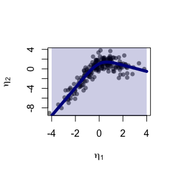

```r
plot(I(eta2-z) ~ eta1, data=d, col=Col("black",0.5), pch=16,
     xlab=expression(eta[1]), ylab=expression(eta[2]), xlim=c(-4,4))
lines(Estimate ~ eta1, data=as.data.frame(p), col="darkblue", lwd=5)
confband(p[,1], lower=p[,4], upper=p[,5], polygon=TRUE,
     border=NA, col=Col("darkblue",0.2))
```

# Cross-validation

```r
m2a <- nonlinear(m2, type="linear", eta2~eta1)
m2b <- nonlinear(m2, type="quadratic", eta2~eta1)
kn1 <- seq(-3,3,length.out=5)
kn2 <- seq(-3,3,length.out=8)
m2c <- nonlinear(m2, type="spline", knots=kn1, eta2~eta1)
m2d <- nonlinear(m2, type="spline", knots=kn2, eta2~eta1)
```

To assess the model fit average RMSE is estimated with 5-fold cross-validation repeated two times

```r
## Scale models in stage 2 to allow for a fair RMSE comparison
d0 <- d
for (i in endogenous(m2))
    d0[,i] <- scale(d0[,i],center=TRUE,scale=TRUE)
## Repeated 5-fold cross-validation:
ff <- lapply(list(linear=m2a,quadratic=m2b,spline4=m2c,spline6=m2d),
        function(m) function(data,...) twostage(m1,m,data=data,stderr=FALSE,control=list(start=coef(e0),contrain=TRUE)))
fit.cv <- cv(ff,data=d,K=5,rep=2,mc.cores=parallel::detectCores(),seed=1)
```

```r
summary(fit.cv)
```

```
#>       Length Class  Mode
#> cv    40     -none- numeric
#> call   7     -none- call
#> names  4     -none- character
#> rep    1     -none- numeric
#> folds  1     -none- numeric
```

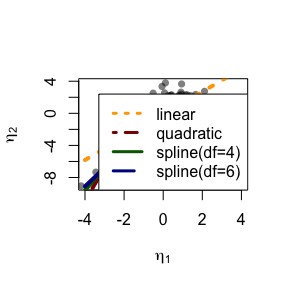

```r
fit <- lapply(list(m2a,m2b,m2c,m2d),
         function(x) {
         e <- twostage(m1,x,data=d)
         pr <- cbind(eta1=newd$eta1,predict(e,newdata=newd$eta1,x=TRUE))
         return(list(estimate=e,predict=as.data.frame(pr)))
         })

plot(I(eta2-z) ~ eta1, data=d, col=Col("black",0.5), pch=16,
     xlab=expression(eta[1]), ylab=expression(eta[2]), xlim=c(-4,4))
col <- c("orange","darkred","darkgreen","darkblue")
lty <- c(3,4,1,5)
for (i in seq_along(fit)) {
    with(fit[[i]]$pr, lines(eta2 ~ eta1, col=col[i], lwd=4, lty=lty[i]))
}
legend("bottomright",
      c("linear","quadratic","spline(df=4)","spline(df=6)"),
      col=col, lty=lty, lwd=3)
```

For convenience, the function `twostageCV` can be used to do the cross-validation (also for choosing the mixture distribution via the ``nmix`` argument, see the section below). For example,

```r
selmod <- twostageCV(m1, m2, data=d, df=2:4, nmix=1:2,
        nfolds=2, rep=1, mc.cores=parallel::detectCores())
```

applies cross-validation (here just 2 folds for simplicity) to select the best splines with degrees of freedom varying from from 1-3 (the linear model is automatically included)

```r
selmod
```

```
#>        Length Class               Mode
#> model1 11     summary.lvm.mixture list
#> AIC1    2     -none-              numeric
#> cv      4     -none-              numeric
#> knots   4     -none-              list
#> model2 11     summary.lvmfit      list
```

# Specification of general functional forms

Next, we show how to specify a general functional relation of multiple different latent or exogenous variables. This is achieved via the `predict.fun` argument. To illustrate this we include interactions between the latent variable $\eta_{1}$ and a dichotomized version of the covariate $z$

```r
d$g <- (d$z<0)*1 ## Group variable
mm1 <- regression(m1, ~g)  # Add grouping variable as exogenous variable (effect specified via 'predict.fun')
mm2 <- regression(m2, eta2~ u1+u2+u1:g+u2:g+z)
pred <- function(mu,var,data,...) {
    cbind("u1"=mu[,1],"u2"=mu[,1]^2+var[1],
      "u1:g"=mu[,1]*data[,"g"],"u2:g"=(mu[,1]^2+var[1])*data[,"g"])
}
ee1 <- twostage(mm1, model2=mm2, data=d, predict.fun=pred)
estimate(ee1,keep="eta2~u",regex=TRUE)
```

```
#>           Estimate Std.Err   2.5% 97.5% P-value
#> eta2~u1     0.9891  17.805 -33.91 35.89  0.9557
#> eta2~u2    -0.3962   9.971 -19.94 19.15  0.9683
#> eta2~u1:g   0.4487  13.679 -26.36 27.26  0.9738
#> eta2~u2:g   0.0441   7.178 -14.02 14.11  0.9951
```

A formal test show no statistically significant effect of this interaction

```r
summary(estimate(ee1,keep="(:g)", regex=TRUE))
```

```
#> Call: estimate.default(x = ee1, keep = "(:g)", regex = TRUE)
#> __________________________________________________
#>           Estimate Std.Err   2.5% 97.5% P-value
#> eta2~u1:g   0.4487  13.679 -26.36 27.26  0.9738
#> eta2~u2:g   0.0441   7.178 -14.02 14.11  0.9951
#>
#>  Null Hypothesis:
#>   [eta2~u1:g] = 0
#>   [eta2~u2:g] = 0
#>
#> chisq = 0.0016, df = 2, p-value = 0.9992
```

# Mixture models

Lastly, we demonstrate how the distributional assumptions of stage 1 model can be relaxed by letting the conditional distribution of the latent variable given covariates follow a Gaussian mixture distribution. The following code explictly defines the parameter constraints of the model by setting the intercept of the first indicator variable, $x_{1}$, to zero and the factor loading parameter of the same variable to one.

```r
m1 <- baptize(m1)  ## Label all parameters
intercept(m1, ~x1+eta1) <- list(0,NA) ## Set intercept of x1 to zero. Remove the label of eta1
regression(m1,x1~eta1) <- 1 ## Factor loading fixed to 1
```

The mixture model may then be estimated using the `mixture` method (note, this requires the `mets` package to be installed), where the Parameter names shared across the different mixture components given in the `list` will be constrained to be identical in the mixture model. Thus, only the intercept of $\eta_{1}$ is allowed to vary between the mixtures.

```r
set.seed(1)
em0 <- mixture(m1, k=2, data=d)
```

To decrease the risk of using a local maximizer of the likelihood we can rerun the estimation with different random starting values

```r
em0 <- NULL
ll <- c()
for (i in 1:5) {
    set.seed(i)
    em <- mixture(m1, k=2, data=d, control=list(trace=0))
    ll <- c(ll,logLik(em))
    if (is.null(em0) || logLik(em0)<tail(ll,1))
    em0 <- em
}
```

```r
summary(em0)
```

```
#> Cluster 1 (n=162, Prior=0.776):
#> --------------------------------------------------
#>                     Estimate Std. Error Z value  Pr(>|z|)
#> Measurements:
#>    x1~eta1           1.00000
#>    x2~eta1           0.99581  0.07940   12.54099   <1e-12
#>    x3~eta1           1.06345  0.08436   12.60541   <1e-12
#> Regressions:
#>    eta1~z            1.06675  0.08527   12.50989   <1e-12
#> Intercepts:
#>    x1                0.00000
#>    x2                0.03845  0.09890    0.38883 0.6974
#>    x3               -0.02549  0.10333   -0.24667 0.8052
#>    eta1              0.20925  0.13162    1.58984 0.1119
#> Residual Variances:
#>    x1                0.98540  0.13316    7.40025
#>    x2                0.97180  0.13156    7.38695
#>    x3                1.01316  0.14294    7.08815
#>    eta1              0.29046  0.11129    2.61004
#>
#> Cluster 2 (n=38, Prior=0.224):
#> --------------------------------------------------
#>                     Estimate Std. Error Z value  Pr(>|z|)
#> Measurements:
#>    x1~eta1           1.00000
#>    x2~eta1           0.99581  0.07940   12.54099   <1e-12
#>    x3~eta1           1.06345  0.08436   12.60541   <1e-12
#> Regressions:
#>    eta1~z            1.06675  0.08527   12.50989   <1e-12
#> Intercepts:
#>    x1                0.00000
#>    x2                0.03845  0.09890    0.38883 0.6974
#>    x3               -0.02549  0.10333   -0.24667 0.8052
#>    eta1             -1.44290  0.25867   -5.57812 2.431e-08
#> Residual Variances:
#>    x1                0.98540  0.13316    7.40025
#>    x2                0.97180  0.13156    7.38695
#>    x3                1.01316  0.14294    7.08815
#>    eta1              0.29046  0.11129    2.61004
#> --------------------------------------------------
#> AIC= 1958.803
#> ||score||^2= 8.81839e-06
```

Measured by AIC there is a slight improvement in the model fit using the mixture model

```r
e0 <- estimate(m1,data=d)
AIC(e0,em0)
```

```
#>     df      AIC
#> e0  10 1961.839
#> em0 12 1958.803
```

The spline model may then be estimated as before with the `two-stage` method

```r
em2 <- twostage(em0,m2,data=d)
em2
```

```
#>                      Estimate Std. Error   Z-value   P-value
#> Measurements:
#>    y2~eta2            0.97823    0.16298   6.00228 1.946e-09
#>    y3~eta2            1.04530    0.10922   9.57068    <1e-12
#> Regressions:
#>    eta2~z             1.02884   20.08620   0.05122    0.9591
#>    eta2~eta1_1        2.80413   44.84857   0.06252    0.9501
#>    eta2~eta1_2       -0.02249    6.57553  -0.00342    0.9973
#>    eta2~eta1_3       -0.17333   19.50620  -0.00889    0.9929
#>    eta2~eta1_4        0.38672   22.12310   0.01748    0.9861
#> Intercepts:
#>    y2                -0.12171    0.11148  -1.09174    0.2749
#>    y3                -0.09870    0.10580  -0.93292    0.3509
#>    eta2               2.12372  112.74655   0.01884     0.985
#> Residual Variances:
#>    y1                 1.31872    0.77923   1.69233
#>    y2                 1.09690    1.23378   0.88906
#>    y3                 0.81345    1.13831   0.71461
#>    eta2               1.99590    9.18508   0.21730
```

In this example the results are very similar to the Gaussian model:

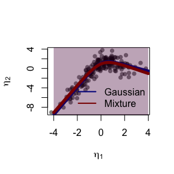

```r
plot(I(eta2-z) ~ eta1, data=d, col=Col("black",0.5), pch=16,
     xlab=expression(eta[1]), ylab=expression(eta[2]))

lines(Estimate ~ eta1, data=as.data.frame(p), col="darkblue", lwd=5)
confband(p[,1], lower=p[,4], upper=p[,5], polygon=TRUE,
     border=NA, col=Col("darkblue",0.2))

pm <- cbind(eta1=newd$eta1,
        estimate(em2, f=function(p) predict(e2,p=p,newdata=newd))$coefmat)
lines(Estimate ~ eta1, data=as.data.frame(pm), col="darkred", lwd=5)
confband(pm[,1], lower=pm[,4], upper=pm[,5], polygon=TRUE,
     border=NA, col=Col("darkred",0.2))
legend("bottomright", c("Gaussian","Mixture"),
       col=c("darkblue","darkred"), lwd=2, bty="n")
```

# Bibliography

[holst_budtzjorgensen_2013] Holst & Budtz-J, Linear latent variable models: the lava-package, *Computational Statistics*, **28(4)**, 1385-1452 (2013). [doi](http://dx.doi.org/10.1007/s00180-012-0344-y). ↩︎

[holst_budtzjorgensen_2020] Klaus Kähler Holst & Esben Budtz-Jørgensen, A two-stage estimation procedure for non-linear structural equation models, *Biostatistics*, **(in press)**, (2020). [doi](http://dx.doi.org/10.1093/biostatistics/kxy082). ↩︎